# HW5 Cheat Sheet

This is a cheat sheet for the fifth homework on centrality. It works through each step in R.

First, you need the following packages.

```r
library(igraph)
library(ggplot2)
library(dplyr)
```

Next, we bring the data into igraph. There are two networks as there are two towns.

```r
k1 <- read.graph("data/Korea1.net", format="pajek")

k2 <- read.graph("data/Korea2.net", format="pajek")
```

```r
adopt1 <- as.matrix(read.table("data/Korea1_adopters.clu", skip=1))

adopt2 <- as.matrix(read.table("data/Korea2_adopters.clu", skip=1))


V(k1)$adopt <- adopt1

V(k2)$adopt <- adopt2
```

Let’s graph the two networks with node color varying by adoption or not.

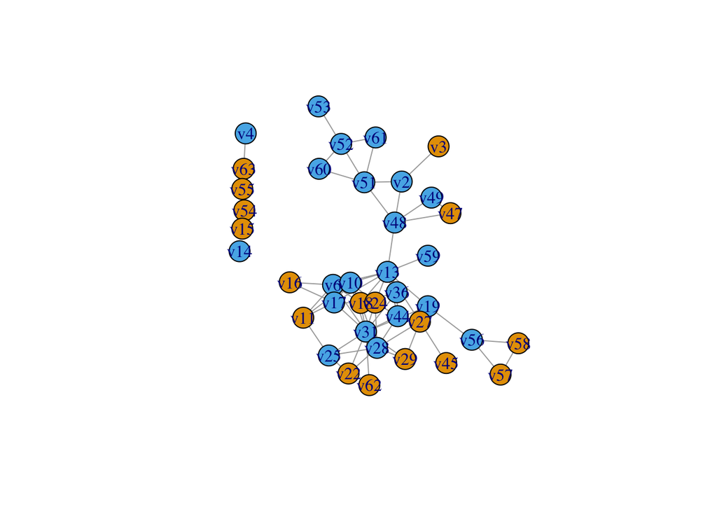

```r
plot(k1, vertex.color=as.factor(V(k1)$adopt))
```

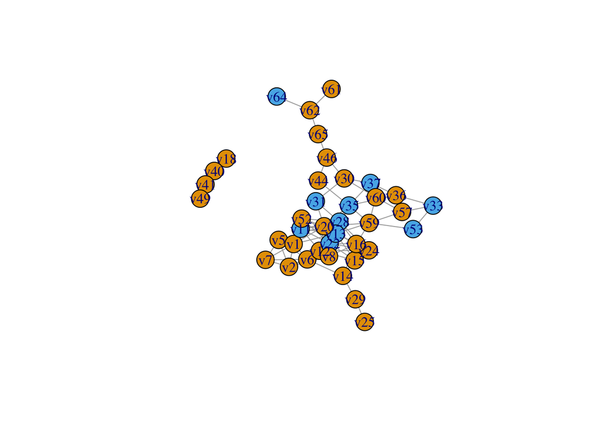

```r
plot(k2, vertex.color=as.factor(V(k2)$adopt))
```

Let’s use degree(g), closeness(g), betweenness(g), and eigen_centrality(g) to calculate various centrality measures for each network.

```r
k1.df <- data.frame(adopt=V(k1)$adopt, deg=degree(k1), close=closeness(k1), btwn=betweenness(k1, normalized=T),
                    eig=eigen_centrality(k1)$vector)

k2.df <- data.frame(adopt=V(k2)$adopt, deg=degree(k2), close=closeness(k2), btwn=betweenness(k2, normalized=T),
                    eig=eigen_centrality(k2)$vector)
```

Let’s use betweenness centralization to compare across the entire graphs. This offers a glimpse of centralization tendencies for the whole thing as opposed to nodal characteristics. I picked this measure because it is a medial one and therefore speaks to diffusion. You can choose another measure, but be sure to have an explanation for your choice.

```r
centr_betw(k1)
```

```
$res
 [1]   4.293651   4.400000   0.000000 102.996825   0.000000  27.798413
 [7]   0.000000  27.798413  93.133333   1.333333  51.800000  13.400000
[13]  15.159524 278.847619  10.377778  22.344444   5.050000  10.266667
[19]   0.000000   0.000000  60.000000   0.000000   0.000000   0.000000
[25]   0.000000 221.000000   0.000000 112.500000  31.000000   0.000000
[31]  31.500000   0.000000   0.000000   0.000000   0.000000   0.000000
[37]   0.000000   0.000000   0.000000

$centralization
[1] 0.3649793

$theoretical_max
[1] 26714
```

```r
mean(adopt1)
```

```
[1] 0.5641026
```

```r
centr_betw(k2)
```

```
$res
 [1]   0.0000000   9.6031191   6.2115440  30.9618853  16.5078255  12.9347375
 [7]  13.2977273   1.2837662   0.5075758  12.6121573   0.0000000  33.0000000
[13]  65.1206349  73.3106172  23.3077922   6.5066101   0.1666667 112.8511128
[19] 131.6335442  52.6718615  98.0078921 136.2270646  71.0416667   8.0711538
[25]   7.8595238 122.0000000   2.0000000  13.7787296  13.9910256  20.5011905
[31]  75.0325758  93.0000000  65.0000000   0.0000000   0.0000000   0.0000000
[37]   0.0000000   0.0000000   0.0000000

$centralization
[1] 0.1491299

$theoretical_max
[1] 26714
```

```r
mean(adopt2)
```

```
[1] 0.2564103
```

We can make a plot that compares how betweenness is distributed between the two villages.

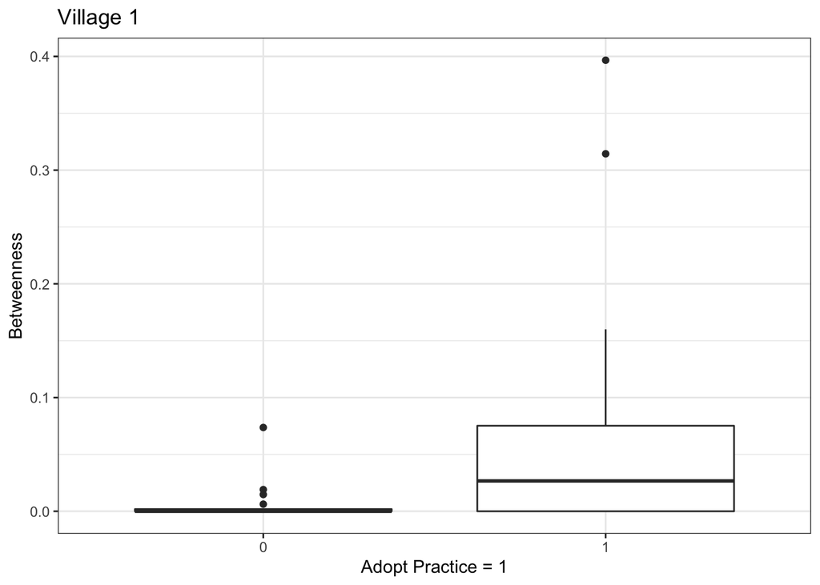

```r
ggplot(k1.df, aes(x=as.factor(adopt), y=btwn)) +
  geom_boxplot() +
  labs(title="Village 1",
        x ="Adopt Practice = 1", y = "Betweenness") +
  theme_bw()
```

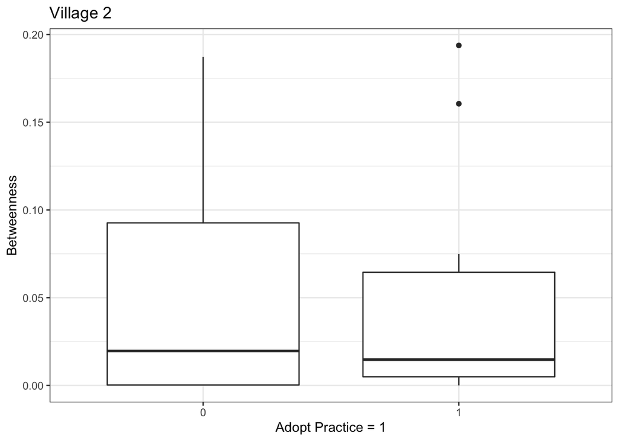

```r
ggplot(k2.df, aes(as.factor(adopt), btwn)) +
  geom_boxplot() +
labs(title="Village 2",
     x ="Adopt Practice = 1", y = "Betweenness") +
theme_bw()
```

We can make this graph more appealing by paneling them.

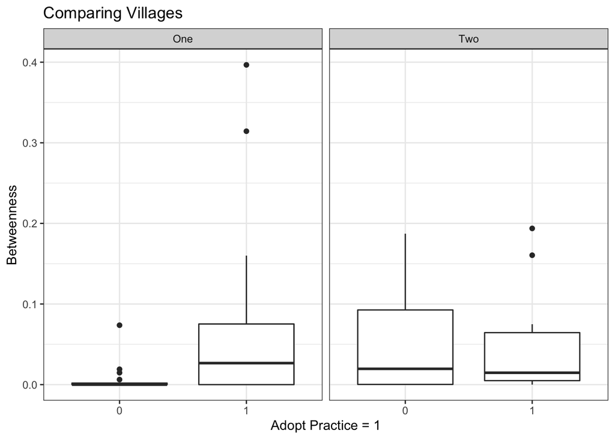

```r
#Let's combine the data frames and use facet() to "panelize" the figures

k1.df$village <- "One"
k2.df$village <- "Two"

ktot.df <- rbind(k1.df, k2.df)

ggplot(ktot.df, aes(x=as.factor(adopt), y=btwn)) +
  geom_boxplot() +
  labs(title="Comparing Villages",
       x ="Adopt Practice = 1", y = "Betweenness") +
  theme_bw()+
  facet_wrap(~ village)
```

We can also construct some formal tests.

```r
t.test(btwn ~ adopt, data = ktot.df,
       var.equal = TRUE, alternative = "less")
```

```
    Two Sample t-test

data:  btwn by adopt
t = -1.7741, df = 76, p-value = 0.04002
alternative hypothesis: true difference in means between group 0 and group 1 is less than 0
95 percent confidence interval:
         -Inf -0.001819706
sample estimates:
mean in group 0 mean in group 1
     0.03259951      0.06222427
```

We could even construct a logistic regression predicting likelihood of adopting the new practice.

```r
areg <- glm(adopt~btwn + as.factor(village), data=ktot.df, family="binomial")

summary(areg)
```

```
Call:
glm(formula = adopt ~ btwn + as.factor(village), family = "binomial",
    data = ktot.df)

Deviance Residuals:
    Min       1Q   Median       3Q      Max
-1.4348  -1.0151  -0.6326   1.1255   1.8483

Coefficients:
                       Estimate Std. Error z value Pr(>|z|)
(Intercept)           -0.008883   0.348900  -0.025  0.97969
btwn                   8.092282   4.347251   1.861  0.06268 .
as.factor(village)Two -1.499363   0.525654  -2.852  0.00434 **
---
Signif. codes:  0 '***' 0.001 '**' 0.01 '*' 0.05 '.' 0.1 ' ' 1

(Dispersion parameter for binomial family taken to be 1)

    Null deviance: 105.60  on 77  degrees of freedom
Residual deviance:  93.44  on 75  degrees of freedom
AIC: 99.44

Number of Fisher Scoring iterations: 4
```